# Regression Analysis 260 Project

November 27, 2020

The following regression analysis is focused on New York City, New York.

Variables:

Target Variables: demographic data (race/ethnicity, age, marital status @ diagnosis (?), % unemployment?, insurance status, median household income, % living less than 150% PVL), facilities, breast cancer mortality, mammography use per geographic location in given year

- Mammouse_crudeprev = Mammography use among women aged 50–74 Years (crude percentage)
- corew_crudeprev = Older adult women aged >=65 Years who are up to date on a core set of clinical preventive services: Flu shot past Year, PPV shot ever, Colorectal cancer screening, and Mammogram past 2 Years paptest_crudeprev = Pap smear tests among adult women aged 21–65 Years within the past 5 years
- air_pollution_particulate_matter_total_population = average concentration of PM2.5 per cubic meter
- binge_drinking_total_population = binge drinking prevalence in adults >= 18 years
- frequent_mental_distress_total_population = poor mental health for >= 14 days over the past 30 days, for those who are >= 18 years
- frequent_physical_distress_total_population = poor physical health for >= 14 days over the past 30 days, for those who are >= 18 years
- high_school_completion_total_population = percent of population >= 18 years who graduated from high school
- housing_with_potential_lead_risk_total_population = housing with potential lead risk
- income_inequality_total_population = percent of households at the extreme of the income index (e.g. a high percent would indicate many people with very little money and/or many people with a lot of wealth)
- obesity_total_population = percent of obese adults
- racial.ethnic_diversity_total_population = distribution of the population by race/ethinic group
- smoking_total_population = percent of total population who smoke
- unemployment_annual_neighborhood.level_total_population = percent of labor force that is unemployed by month
- uninsured_total_population = percent of population between 0-64 years that lacks health insurance
- walkability_total_population = access to amenities via walking

# Mammography use (mammouse_crudeprev) as the outcome variable of interest:

## Multiple Linear Regression Justification

The mammography use variable is numeric, continuous, and non-binary. This eliminates logistic as an option because logistic requires a binary outcome variable. Poisson may be used because prevalence is count data, however this data does not include a time offset, nor is the assumption of variance = mean for the ourcome variable satisfied. Finally, ordinal and categorical cannot be applied due to the prevalence measrues. Therefore, I will begin by a multiple linear regression analysis.

# Model Assumptions:

- E(Y), the outcome variable, is an unknown linear function of X (predictor variables).
- All response errors are independent of each others
- Outcome variables are normally distributed for any covariate.
- There is equal variables for each outcome variable, centered at the mean, for any covariate.

## Verifying Assumptions:

### Normally distributed variables

```r
par(mfrow=c(4,4))
ggplot(df_aw, aes(mammouse_crudeprev)) +
  geom_histogram()
```

[output not shown]

```r
ggplot(df_aw, aes(paptest_crudeprev)) +
  geom_histogram()
```

[output not shown]

```r
ggplot(df_aw, aes(high_school_completion_total_population)) +
  geom_histogram()
```

[output not shown]

```r
ggplot(df_aw, aes(unemployment_annual_neighborhood.level_total_population)) +
  geom_histogram()
```

[output not shown]

```r
ggplot(df_aw, aes(uninsured_total_population)) +
  geom_histogram()
```

[output not shown]

```r
ggplot(df_aw, aes(housing_with_potential_lead_risk_total_population)) +
  geom_histogram()
```

[output not shown]

```r
ggplot(df_aw, aes(air_pollution_particulate_matter_total_population)) +
  geom_histogram()
```

[output not shown]

```r
ggplot(df_aw, aes(binge_drinking_total_population)) +
  geom_histogram()
```

[output not shown]

```r
ggplot(df_aw, aes(diabetes_total_population)) +
  geom_histogram()
```

[output not shown]

```r
ggplot(df_aw, aes(frequent_physical_distress_total_population)) +
  geom_histogram()
```

[output not shown]

```r
ggplot(df_aw, aes(racial.ethnic_diversity_total_population)) +
  geom_histogram()
```

[output not shown]

```r
ggplot(df_aw, aes(corew_crudeprev)) +
  geom_histogram()
```

[output not shown]

```r
ggplot(df_aw, aes(frequent_mental_distress_total_population)) +
  geom_histogram()
```

[output not shown]

```r
ggplot(df_aw, aes(income_inequality_total_population)) +
  geom_histogram()
```

[output not shown]

```r
ggplot(df_aw, aes(obesity_total_population)) +
  geom_histogram()
```

[output not shown]

```r
ggplot(df_aw, aes(smoking_total_population)) +
  geom_histogram()
```

[output not shown]

### QQ Plot

```r
qqnorm(df_aw$mammouse_crudeprev)
```

[output not shown]

```r
qqnorm(df_aw$corew_crudeprev)
```

[output not shown]

```r
qqnorm(df_aw$paptest_crudeprev)
```

[output not shown]

```r
qqnorm(df_aw$air_pollution_particulate_matter_total_population)
```

[output not shown]

```r
qqnorm(df_aw$binge_drinking_total_population)
```

[output not shown]

```r
qqnorm(df_aw$frequent_mental_distress_total_population)
```

[output not shown]

```r
qqnorm(df_aw$frequent_physical_distress_total_population)
```

[output not shown]

```r
qqnorm(df_aw$high_school_completion_total_population)
```

[output not shown]

```r
qqnorm(df_aw$housing_with_potential_lead_risk_total_population)
```

[output not shown]

```r
qqnorm(df_aw$income_inequality_total_population)
```

[output not shown]

```r
qqnorm(df_aw$obesity_total_population)
```

[output not shown]

```r
qqnorm(df_aw$racial.ethnic_diversity_total_population)
```

[output not shown]

```r
qqnorm(df_aw$smoking_total_population)
```

[output not shown]

```r
qqnorm(df_aw$unemployment_annual_neighborhood.level_total_population)
```

[output not shown]

```r
qqnorm(df_aw$uninsured_total_population)
```

[output not shown]

```r
#qqnorm(df_aw$walkability_total_population)
```

## Analysis of singular variables:

```r
# diabetes total population
onecovar_d <- lm(mammouse_crudeprev ~ diabetes_total_population, data = df_aw)
summary(onecovar_d)

# diabetes with squared term
onecovar_d_sq <- lm(mammouse_crudeprev ~ diabetes_total_population + I(paptest_crudeprev^2), data = df_aw)
summary(onecovar_d_sq)

4# anova
anova(onecovar_d, onecovar_d_sq)
```

[output not shown]

```r
# pap test
onecovar_pap <- lm(mammouse_crudeprev ~ paptest_crudeprev, data = df_aw)
summary(onecovar_pap)

# pap test with a squared term
onecovar_pap_sq <- lm(mammouse_crudeprev ~ paptest_crudeprev + I(paptest_crudeprev^2), data = df_aw)
summary(onecovar_pap_sq)

# anova
anova(onecovar_pap, onecovar_pap_sq)
```

[output not shown]

The multiple R-Squared value is lower for the model with just a simple term (P=0.598) compared to the one with the quadratic (P=0.6571). However, the ANOVA indicates that the model with the quadratic is improved. However, this variable is very skewed and seems like a better use as a an outcome variable. However, I will include the simple term in the forward selection.

```r
# Racial and ethnic diversity
onecovar_race <- lm(mammouse_crudeprev ~ racial.ethnic_diversity_total_population, data = df_aw)
summary(onecovar_race)

# Racial and ethnic diversity with a squared term
onecovar_race_sq <- lm(mammouse_crudeprev ~ racial.ethnic_diversity_total_population + I(racial.ethnic_diversity_total_population^2), data = df_aw)
summary(onecovar_race_sq)

# anova
anova(onecovar_race, onecovar_race_sq)
```

[output not shown]

```r
# unemployment rates by neighborhood in percent
onecovar_unemp <- lm(mammouse_crudeprev ~ unemployment_annual_neighborhood.level_total_population, data=df_aw)
summary(onecovar_unemp)

# unemployment rates by neighborhood with a squared term in percent
onecovar_unemp_sq <- lm(mammouse_crudeprev ~ unemployment_annual_neighborhood.level_total_population + I(unemployment_annual_neighborhood.level_total_population^2), data=df_aw)
summary(onecovar_unemp_sq)

# anova
anova(onecovar_unemp, onecovar_unemp_sq)
```

[output not shown]

These models use neighborhood unemployment rates to predict mammography use, where the first model is the simple term and the second model includes the squared term. While both models and both covariates are significant (P < 0.05), the first model has a lower adjusted R-squared value (0.04913), as opposed to the adjusted R-squared in the second model (0.05485).However, since the ANOVA shows that the second model has an improved fit, we will include the squared term.

```r
# uninsured by neighborhood in percent
onecovar_unins <- lm(mammouse_crudeprev ~ uninsured_total_population, data=df_aw)
summary(onecovar_unins)

# uninsured by neighborhood in percent with a squared term
onecovar_unins_sq <- lm(mammouse_crudeprev ~ uninsured_total_population + I(uninsured_total_population^2), data=df_aw)
summary(onecovar_unins_sq)

# anova
anova(onecovar_unins, onecovar_unins_sq)
```

[output not shown]

```r
# smoking by percent
onecovar_smk <- lm(mammouse_crudeprev ~ smoking_total_population,data=df_aw)
summary(onecovar_smk)


# smoking by percent
onecovarsmk_sq <- lm(mammouse_crudeprev ~ smoking_total_population + I(smoking_total_population^2), data=df_aw)
summary(onecovarsmk_sq)

# anova
anova(onecovar_smk, onecovarsmk_sq)
```

[output not shown]

These models predict mammography use by smoking prevalence, the first model just uses a simple term, and the second uses a squared term. In this case, the P-values for the covariates and the models are not significant, however the adjusted R-squared values are both low -0.0004195 for the simple covariate and -0.0007106 for the model with a squared term. However, the ANOVA has a P-value > 0.05, so I will not use the squared term in the final model.

```r
# obesity percentage
onecovar_obs <- lm(mammouse_crudeprev ~ obesity_total_population, data=df_aw)
summary(onecovar_obs)

# obesity percentage squared
onecovar_obs_sq <- lm(mammouse_crudeprev ~ obesity_total_population + I(obesity_total_population^2), data=df_aw)
summary(onecovar_obs_sq)

# anova
anova(onecovar_obs, onecovar_obs_sq)
```

[output not shown]

These models use obesity to predict mammography use. The first model is simple and the second includes a squared term. Both models are significant (P < 0.05). The adjusted R-squared is lower for the simple model 0.2447, compared to 0.2488 in the model with a squared term. Notable, the simple term is not signficant in the second model, but is in the first. However, the ANOVA test shows that the second model significanly improves prediction, so I will incoporate the squared term into the final model.

```r
# income inequality percentage
onecovar_ii <- lm(mammouse_crudeprev ~ income_inequality_total_population, data=df_aw)
summary(onecovar_ii)

# income inequality squared
onecovar_ii_sq <- lm(mammouse_crudeprev ~ income_inequality_total_population + I(income_inequality_total_population^2), data=df_aw)
summary(onecovar_ii_sq)

# anova
anova(onecovar_ii, onecovar_ii_sq)
```

[output not shown]

These models use income inequality to predict mammography use, with the first using a simple term and the second using simple and quadratic terms. Both are significant with significant covariates (P < 0.05). However, the model with just the simple term has a lower adjusted R-squared of 0.002687 compared to the 0.007365 of the model with the squared term. However, the ANOVA test shows that the second model significanly improves prediction, so I will incoporate the squared term into the final model.

```r
# high school completion percentage
onecovar_hs <- lm(mammouse_crudeprev ~ high_school_completion_total_population, data=df_aw)
summary(onecovar_hs)

# high school completion percentage squared
onecovar_hs_sq <- lm(mammouse_crudeprev ~ high_school_completion_total_population + I(high_school_completion_total_population^2), data=df_aw)
summary(onecovar_hs_sq)

anova(onecovar_hs, onecovar_hs_sq)
```

[output not shown]

These models show how high scool graudation rate can predict mammography use. All covariates and both models are significant, and the simple model has a lower adjusted R-squared (0.0334) compared to the squared model (0.03831). However, the ANOVA test shows that the second model significanly improves prediction, so I will incoporate the squared term into the final model.

```r
#physical distress percentage
onecovar_pd <- lm(mammouse_crudeprev ~ frequent_physical_distress_total_population, data=df_aw)
summary(onecovar_pd)

# physical distress percentage squared
onecovar_pd_sq <- lm(mammouse_crudeprev ~ frequent_physical_distress_total_population + I(frequent_physical_distress_total_population^2), data=df_aw)
summary(onecovar_pd_sq)

# anova
anova(onecovar_pd, onecovar_pd_sq)
```

[output not shown]

```r
# mental distress percentage
onecovar_md <- lm(mammouse_crudeprev ~ frequent_physical_distress_total_population, data=df_aw)
summary(onecovar_md)

# mental distress percentage squared
onecovar_md_sq <- lm(mammouse_crudeprev ~ frequent_mental_distress_total_population + I(frequent_mental_distress_total_population^2), data=df_aw)
summary(onecovar_md_sq)

# anova
anova(onecovar_md, onecovar_md_sq)
```

[output not shown]

```r
# overall health
onecovar_oh <- lm(mammouse_crudeprev ~ corew_crudeprev, data=df_aw)
summary(onecovar_oh)

# overall health squared
onecovar_oh_sq <- lm(mammouse_crudeprev ~ corew_crudeprev + I(corew_crudeprev^2), data=df_aw)
summary(onecovar_oh_sq)

# anova
anova(onecovar_oh, onecovar_oh_sq)
```

[output not shown]

These models shows how wellness considerations (i.e. getting vaccinations, getting pap smears) may predict mammography use. The adjusted R-squared value is greater for the model with just the simple term, and the ANOVA has a P-value > 0.05, so the squared term does not appear to improve the model.

```r
# lead exposure
onecovar_lead <- lm(mammouse_crudeprev ~ housing_with_potential_lead_risk_total_population, data=df_aw)
summary(onecovar_lead)

# binge drinking
onecovar_binge <- lm(mammouse_crudeprev ~ binge_drinking_total_population, data=df_aw)
summary(onecovar_binge)

# air pollution
onecovar_pol <- lm(mammouse_crudeprev ~ air_pollution_particulate_matter_total_population, data=df_aw)
summary(onecovar_pol)

# walkability - ALL NA'S
# onecovar_wlk <- lm(mammouse_crudeprev ~ walkability_total_population, data=df_aw)
# summary(onecovar_wlk)
```

[output not shown]

The effect of lead expsosure on breast cancer appears to be significant, however, it is important to note that lead exposure may also be correlated with demographic variables i.e. income, location, which also have influence on mammography use. We may test for effect modification and confounding later in the regression analysis.

# Analysis of effect modification and confounding

## Analysis of effect modification

Effect modification: * mental x physical distress * binge drinking x smoking * highschool graduation x unemployment

### mental distress x physical distress

```r
# mental distress x physical distress
dist_aw <- lm(mammouse_crudeprev ~ frequent_physical_distress_total_population + frequent_mental_distress_total_population, data=df_aw)
summary(dist_aw)

# model with interaction term
em_dist_aw <- lm(mammouse_crudeprev ~ frequent_physical_distress_total_population + frequent_mental_distress_total_population + frequent_physical_distress_total_population*frequent_mental_distress_total_population, data=df_aw)
summary(em_dist_aw)

# anova test
anova(dist_aw, em_dist_aw)
```

[output not shown]

The above code test for interaction between frequent mental and physical distress. Intuitively, there may be interaction between these two variables because physical distress may beget mental distress, and vice versa. For example, it may be the case that as physical distress increases, mental distress increases, too.

### binge drinking x smoking

```r
# binge drinking x smoking
binsmk_aw <- lm(mammouse_crudeprev ~ binge_drinking_total_population + smoking_total_population, data=df_aw)
summary(binsmk_aw)

# model with interaction term
em_binsmk_aw <- lm(mammouse_crudeprev ~ binge_drinking_total_population + smoking_total_population + binge_drinking_total_population*smoking_total_population, data=df_aw)
summary(em_binsmk_aw)

# anova test
anova(binsmk_aw, em_binsmk_aw)
```

[output not shown]

The above code tests for interaction between smoking and drinking. These two variables often correspond with each other, where people who smoke are more likely to drink, and vice versa.

### highschool graduation x unemployment

```r
# highschool graduation x unemployment
grademp_aw <- lm(mammouse_crudeprev ~ high_school_completion_total_population + unemployment_annual_neighborhood.level_total_population, data=df_aw)
summary(grademp_aw)

# model with interaction term
em_grademp_aw <- lm(mammouse_crudeprev ~ high_school_completion_total_population + unemployment_annual_neighborhood.level_total_population + high_school_completion_total_population*unemployment_annual_neighborhood.level_total_population, data=df_aw)
summary(em_grademp_aw)

# anova test
anova(grademp_aw, em_grademp_aw)
```

[output not shown]

The above code tests for interaction between high school graduation rate and unemployment. High school graduation is a common requirement for jobs, and so we might expect that as high school gradution increases, unemployment decreases, and vice versa.

## Analysis of confounding

Confounding: * unemployment x uninsured * highschool graduation x unemployment

### unemployment x uninsured

```r
# Does employment confound insurance coverage?
ins_aw <- lm(mammouse_crudeprev ~ uninsured_total_population, data=df_aw)
summary(ins_aw)

insemp_aw <- lm(mammouse_crudeprev ~ uninsured_total_population + unemployment_annual_neighborhood.level_total_population, data=df_aw)
summary(insemp_aw)

# crude - adjusted / adjused coefficients for insurance coverage
coeff_diff <- 100*(((coef(ins_aw)[2]-coef(insemp_aw)[2])/coef(insemp_aw)[2]))
print(coeff_diff)
```

[output not shown]

There may be confounding between insurance coverage and unemployment. For example, the effect of unemployment on mammography use may be significant, but the real association may be between unsinsurance and unemployment. In this case, the unemployment causes a lack of insurance, which then affects people’s ability to get a mammography.

There is a 13.5% percent difference between the coefficient for insurance coverage between the crude and adjusted models. This is relatively high, which indicates that there is some confounding.

### highschool graduation x unemployment

```r
# Does highschool graduation confound unemployment?
emp_aw <- lm(mammouse_crudeprev ~ unemployment_annual_neighborhood.level_total_population, data=df_aw)
summary(emp_aw)

emp_hs_aw <- lm(mammouse_crudeprev ~ high_school_completion_total_population + unemployment_annual_neighborhood.level_total_population, data=df_aw)
summary(emp_hs_aw)

# crude - adjusted / adjused coefficients for insurance coverage
coeff_diff2 <- 100*(((coef(emp_aw)[2]-coef(emp_hs_aw)[2])/coef(emp_hs_aw)[2]))
print(coeff_diff2)
```

[output not shown]

There may be confounding between high school graduation and unemployment. Where high school graduation may be seem to have an association with mammography use, however, this association is due to the back door pathway of employment, which enables access to healthcare.

# Selection

## Forward selection

```r
# forward model selection

full_mod <-lm(mammouse_crudeprev ~ high_school_completion_total_population + unemployment_annual_neighborhood.level_total_population + high_school_completion_total_population*unemployment_annual_neighborhood.level_total_population + binge_drinking_total_population + smoking_total_population + binge_drinking_total_population*smoking_total_population + frequent_physical_distress_total_population + frequent_mental_distress_total_population + frequent_physical_distress_total_population*frequent_mental_distress_total_population + corew_crudeprev + I(frequent_mental_distress_total_population^2) + I(frequent_physical_distress_total_population^2) + I(high_school_completion_total_population^2) + income_inequality_total_population + I(income_inequality_total_population^2) + obesity_total_population + I(obesity_total_population^2) + smoking_total_population + I(uninsured_total_population^2) + I(unemployment_annual_neighborhood.level_total_population^2) + racial.ethnic_diversity_total_population + I(racial.ethnic_diversity_total_population^2) +  paptest_crudeprev + diabetes_total_population, family = gaussian(), data=df_aw)

mod_forw <- step(full_mod, direction = "forward")
summary(mod_forw)
```

[output not shown]

Resulting model:

```r
final_mod <- lm(mammouse_crudeprev ~ high_school_completion_total_population + unemployment_annual_neighborhood.level_total_population + binge_drinking_total_population +  smoking_total_population + frequent_physical_distress_total_population + frequent_mental_distress_total_population + corew_crudeprev + I(frequent_mental_distress_total_population^2) + I(frequent_physical_distress_total_population^2) + I(high_school_completion_total_population^2) + income_inequality_total_population + I(income_inequality_total_population^2) + obesity_total_population  + I(obesity_total_population^2) + high_school_completion_total_population:unemployment_annual_neighborhood.level_total_population + binge_drinking_total_population:smoking_total_population + frequent_physical_distress_total_population:frequent_mental_distress_total_population + paptest_crudeprev + I(uninsured_total_population^2) + racial.ethnic_diversity_total_population  + I(racial.ethnic_diversity_total_population^2) + paptest_crudeprev + diabetes_total_population, data = df_aw)
summary(final_mod)
```

```
##
## Call:
## lm(formula = mammouse_crudeprev ~ high_school_completion_total_population +
##     unemployment_annual_neighborhood.level_total_population +
##     binge_drinking_total_population + smoking_total_population +
##     frequent_physical_distress_total_population + frequent_mental_distress_total_population +
##     corew_crudeprev + I(frequent_mental_distress_total_population^2) +
##     I(frequent_physical_distress_total_population^2) + I(high_school_completion_total_population^2) +
##     income_inequality_total_population + I(income_inequality_total_population^2) +
##     obesity_total_population + I(obesity_total_population^2) +
##     high_school_completion_total_population:unemployment_annual_neighborhood.level_total_population +
##     binge_drinking_total_population:smoking_total_population +
##     frequent_physical_distress_total_population:frequent_mental_distress_total_population +
##     paptest_crudeprev + I(uninsured_total_population^2) + racial.ethnic_diversity_total_population +
##     I(racial.ethnic_diversity_total_population^2) + paptest_crudeprev +
##     diabetes_total_population, data = df_aw)
##
## Residuals:
##     Min      1Q  Median      3Q     Max
## -4.3541 -0.4607  0.0608  0.5569  4.7405
##
## Coefficients:
##                                                                                                   Estimate
## (Intercept)                                                                                      3.617e+01
## high_school_completion_total_population                                                          7.162e-02
## unemployment_annual_neighborhood.level_total_population                                         -1.206e-01
## binge_drinking_total_population                                                                 -5.681e-01
## smoking_total_population                                                                        -4.526e-01
## frequent_physical_distress_total_population                                                     -2.766e+00
## frequent_mental_distress_total_population                                                        2.154e+00
## corew_crudeprev                                                                                  1.503e-01
## I(frequent_mental_distress_total_population^2)                                                  -2.942e-02
## I(frequent_physical_distress_total_population^2)                                                 2.215e-02
## I(high_school_completion_total_population^2)                                                    -8.033e-04
## income_inequality_total_population                                                               6.379e-03
## I(income_inequality_total_population^2)                                                         -1.868e-04
## obesity_total_population                                                                        -1.315e-01
## I(obesity_total_population^2)                                                                    1.226e-03
## paptest_crudeprev                                                                                6.158e-01
## I(uninsured_total_population^2)                                                                  8.342e-04
```

[output cut: 94 more lines]

```
## paptest_crudeprev                                                                               ***
## I(uninsured_total_population^2)                                                                 ***
## racial.ethnic_diversity_total_population
## I(racial.ethnic_diversity_total_population^2)
## diabetes_total_population                                                                       ***
## high_school_completion_total_population:unemployment_annual_neighborhood.level_total_population ***
## binge_drinking_total_population:smoking_total_population                                        **
## frequent_physical_distress_total_population:frequent_mental_distress_total_population           **
## ---
## Signif. codes:  0 '***' 0.001 '**' 0.01 '*' 0.05 '.' 0.1 ' ' 1
##
## Residual standard error: 0.96 on 2079 degrees of freedom
##   (36 observations deleted due to missingness)
## Multiple R-squared:  0.8872, Adjusted R-squared:  0.886
## F-statistic:   743 on 22 and 2079 DF,  p-value: < 2.2e-16
```

This model appears to predict data relatively well, with an adjusted r-squared of 0.886. However, it is complicated, and thus very hard to interpret. Fortunately, we will use this model to inform decision trees and random forests.

# Machine Learning

## Decision tree based on variables from foward selection

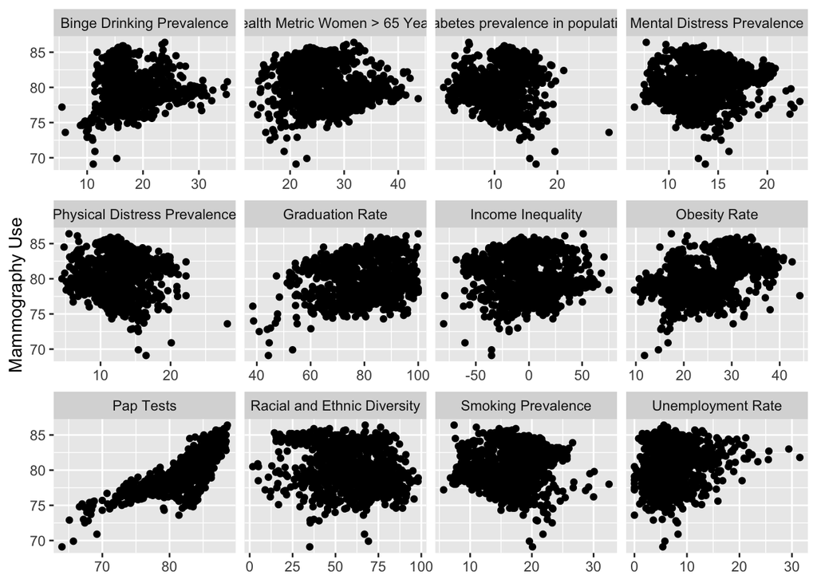

```r
set.seed(42)

# selecting relevant variables from forward regression
df_aw_noNA <- df_aw %>% select(mammouse_crudeprev, high_school_completion_total_population, unemployment_annual_neighborhood.level_total_population, binge_drinking_total_population, smoking_total_population, frequent_physical_distress_total_population, frequent_mental_distress_total_population, corew_crudeprev, income_inequality_total_population, obesity_total_population, paptest_crudeprev,racial.ethnic_diversity_total_population, diabetes_total_population)

# only rows without NA values
df_aw_train <- df_aw_noNA[complete.cases(df_aw_noNA),]


# split into training and testing data
index_train <- createDataPartition(y = df_aw_train$mammouse_crudeprev, times = 1, p= 0.5, list=FALSE)


train_set <- slice(df_aw_train, index_train)
test_set <- slice(df_aw_train, -index_train)

# graph to assess relationship
train_set %>%
  gather(predictor, value, c(high_school_completion_total_population, unemployment_annual_neighborhood.level_total_population, binge_drinking_total_population, smoking_total_population, frequent_physical_distress_total_population, frequent_mental_distress_total_population, corew_crudeprev, income_inequality_total_population, obesity_total_population, paptest_crudeprev, racial.ethnic_diversity_total_population, diabetes_total_population)) %>%
  ggplot(aes(x = value, y = mammouse_crudeprev)) +
  geom_point() +
  facet_wrap(~ predictor, scales = 'free_x',
             labeller =
               as_labeller(c("high_school_completion_total_population"="Graduation Rate",
                             "unemployment_annual_neighborhood.level_total_population" = "Unemployment Rate",
                             "binge_drinking_total_population" = "Binge Drinking Prevalence",
                             "smoking_total_population" = "Smoking Prevalence",
                             "frequent_physical_distress_total_population" = "Physical Distress Prevalence",
                             "frequent_mental_distress_total_population" = "Mental Distress Prevalence",
                             "corew_crudeprev" = "Health Metric Women > 65 Years",
                             "income_inequality_total_population" = "Income Inequality",
                             "obesity_total_population" = "Obesity Rate",
                             "paptest_crudeprev" = "Pap Tests",
                             "racial.ethnic_diversity_total_population" = "Racial and Ethnic Diversity",
                             "diabetes_total_population" = "Diabetes prevalence in population"))) +
  xlab(NULL) + ylab("Mammography Use")
```

[figure not shown]

```r
# fitting a model
fit <- lm(mammouse_crudeprev ~ high_school_completion_total_population + unemployment_annual_neighborhood.level_total_population + binge_drinking_total_population +  smoking_total_population + frequent_physical_distress_total_population + frequent_mental_distress_total_population + corew_crudeprev +  income_inequality_total_population + obesity_total_population + paptest_crudeprev,racial.ethnic_diversity_total_population + diabetes_total_population, data = train_set, family = "gaussian")

# fitting a decision tree
fit_tree = tree(mammouse_crudeprev ~., data = train_set)

# plot decision tree - this code chunk fails sometimes?
plot(fit_tree)
text(fit_tree, pretty = 0)
```